# LightGBMと勾配ブースティング

UPDATE: 2024-04-29 17:20:11.729473

# はじめに

このノートではLightGBMを理解するために、LightGBMの基礎となっている勾配ブースティングのアルゴリズムについて理解する。LightGBMの特徴については別のノートで取り上げる予定ではあるが、ベースは勾配ブースティングのアルゴリズムなので、まずは勾配ブースティングを理解する。下記のStatQuestを参考にしている。

- [Gradient Boost Part 2 (of 4): Regression Details](https://www.youtube.com/watch?v=2xudPOBz-vs&t=1169s)
- [Gradient Boost Part 3 (of 4): Classification](https://www.youtube.com/watch?v=jxuNLH5dXCs&t=1s)
- [Gradient Boost Part 4 (of 4): Classification Details](https://www.youtube.com/watch?v=StWY5QWMXCw&t=2s)

## 勾配ブースティング(回帰)

下記の簡単なデータを例に勾配ブースティングのアルゴリズムの理解を深める。

| No | Height | color | gender | weight(Y) |
| --- | --- | --- | --- | --- |
| 1 | 1.6 | blue | male | 88 |
| 2 | 1.6 | green | female | 76 |
| 3 | 1.5 | blue | female | 56 |

### Step1: モデルの初期化

まずは$Data\{ (x_{i}, y_{i})\}_{i=1}^{n}$と微分可能な損失関数$L(y_{i}, \gamma)$を用意する。損失関数については、2乗誤差を使用する。$\gamma$は予測値である。

$$\begin{eqnarray}
\text{Step1} &:& \text{Initialize model with a constant value}
\\
F_{0}(x) &=& \underset{\gamma} {\operatorname{argmin}}
\sum_{i=1}^{n}L(y_{i}, \gamma)
\end{eqnarray}$$
これは損失関数(2乗誤差)を最小にするということなので、今回のデータであれば、下記のようになる。

$$\begin{eqnarray}
\sum_{i=1}^{n}L(y_{i}, \gamma) = \frac{1}{2}(88-pred)^{2} +
\frac{1}{2}(76-pred)^{2} + \frac{1}{2}(56-pred)^{2}
\end{eqnarray}$$

予測値$\gamma$について、最小にするということなので、微分して0とおく。

$$\begin{eqnarray}
\frac{d \sum_{i=1}^{n}L(y_{i}, \gamma)}{d \gamma} &=&
\frac{1}{2}(88-pred)^{2} + \frac{1}{2}(76-pred)^{2} +
\frac{1}{2}(56-pred)^{2}=0 \\
\end{eqnarray}$$

下記の通り計算すると$F_{0}(x)=73.3$とわかる。これでStep1は完了。

$$\begin{eqnarray}
0 &=& -(88-pred)-(76-pred)-(56-pred) \\
0 &=& -88+pred-76+pred-56+pred\\
3pred &=& 88 + 76 + 56 \\
pred &=&\frac{88 + 76 + 56}{3} \\
pred &=& 73.3
\end{eqnarray}$$

### Step2-A: 残差を計算する

このステップでは、下記の式をもとに残差$r_{im}$を計算する。$m$はブースティング回数である。$F(x)=F_{m-1}(x)$は今回は$m=1$なので、$F(x)=F_{0}(x)$となる。

$$\begin{eqnarray}
\text{Step2-A} &:& \text{Compute} \ \ r_{im} \\
r_{im} &=& - \left[ \frac{\partial L(y_{i}, F(x_{i}))}{\partial
F(x_{i})}\right]_{F(x)=F_{m-1}(x)}, for \ i=1...n
\end{eqnarray}$$

この部分がゴツく見えるが、今回の場合、ここは残差になる。なぜなら、損失関数を予測値で微分すると、残差がでてくるからである。

$$\begin{eqnarray}
r_{im} = - \left[ \frac{\partial L(y_{i}, F_{0}(x))}{\partial
F_{0}(x)}\right] &=& - \frac{\frac{1}{2}(y_{i} -
F_{0}(x))^2}{\partial F_{0}(x)} \\
&=& -[ -(y_{i} - F_{0}(x))] \\
&=& (y_{i} - F_{0}(x)) \\
&=& (y_{i} - 73.3)
\end{eqnarray}$$

これが勾配ブースティングの勾配に当たる部分であり、$r_{im}$は疑似残差である。 先程の表に、情報を追加しておく。

| No | Height | color | gender | weight(Y) | $r_{i,1}$ |
| --- | --- | --- | --- | --- | --- |
| 1 | 1.6 | blue | male | 88 | 14.7 |
| 2 | 1.6 | green | female | 76 | 2.7 |
| 3 | 1.5 | blue | female | 56 | -17.3 |

### Step2-B: 残差に回帰木を作成する

さきほど計算した残差に対して、回帰木を作成する。$m$はブースティング回数で、$j$はリーフの数。

$$\begin{eqnarray}
\text{Step2-B} &:& \text{Fit a regression tree to the} \ \
r_{im} \text{values and create terminal regions} \ \ R_{jm}, \text{for}
\ j = 1...J_m\\
\end{eqnarray}$$

ここでは下記の回帰木ができたとする。数字はさきほど計算した残差で、丸括弧はレコードのNoを表す。

```
Height < 1.55
 └ R_{1,1}: Left(yes): -17.3(3)
 └ R_{1,2}: Right(No): 14.7(1),2.7(2)
```

### Step2-C: 各リーフの残差を最小化する

このステップでは、各リーフごとに、残差を最小にしていく。$m$はブースティング回数で、$j$はリーフの数。

$$\begin{eqnarray}
\text{Step2-C} &:& \text{For} \ j = 1...J_m \ \ \text{compute} \
\ \gamma_{jm} = \underset{\gamma} {\operatorname{argmin}} \sum_{x_{i}
\in R_{ij}} L(y_{i}, F_{m-1}(x_{i})+\gamma)
\\
\end{eqnarray}$$

さきほど計算したリーフの場合、2つのリーフ(片方は1レコード)しかないので、シンプルに計算できる。

$$\begin{eqnarray}
\gamma_{1,1} &=& \underset{\gamma} {\operatorname{argmin}}
\sum_{x_{i} \in R_{i1}} L(y_{i}, F_{0}(x_{i})+\gamma) \\
&=& \frac{1}{2}( y_{i}-(F_{0}(x_{3})+\gamma) )^{2} \\
&=& \frac{1}{2}( 56-73.3-\gamma )^{2} \\
&=& \frac{1}{2}( -17.3-\gamma )^{2}
\end{eqnarray}$$

残差を最小にするために、微分して0とすると、$\gamma_{1,1} = -17.3$となる。

$$\begin{eqnarray}
\frac{\partial \frac{1}{2}( -17.3-\gamma )^{2}}{\partial \gamma}
&=& (-17.3 - \gamma)*-1 = 0 \\
17.3 + \gamma &=& 0 \\
\gamma &=& -17.3
\end{eqnarray}$$

$\gamma_{2,1}$も同様に計算する。

$$\begin{eqnarray}
\gamma_{2,1} &=& \underset{\gamma} {\operatorname{argmin}}
\sum_{x_{i} \in R_{i2}} L(y_{i}, F_{0}(x_{i})+\gamma) \\
&=& \frac{1}{2}( y_{1}-(F_{0}(x_{3})+\gamma) )^{2} +
\frac{1}{2}( y_{2}-(F_{0}(x_{3})+\gamma) )^{2}\\
&=& \frac{1}{2}( 88-73.3-\gamma) )^{2} + \frac{1}{2}(
76-73.3-\gamma )^{2}\\
&=& \frac{1}{2}( 14.7-\gamma) )^{2} + \frac{1}{2}( 2.7-\gamma
)^{2}\\
\end{eqnarray}$$

残差を最小にするために、微分して0とすると、$\gamma_{2,1} = 8.7$となる。

$$\begin{eqnarray}
\frac{\partial \frac{1}{2}( 14.7-\gamma) )^{2} + \frac{1}{2}( 2.7-\gamma
)^{2}}{\partial \gamma} &=& (14.7 - \gamma)*-1 + (2,7 -
\gamma)*-1 = 0 \\
-14.7 + \gamma - 2.7 + \gamma &=& 0 \\
\gamma &=& \frac{14.7 + 2.7}{2} \\
\gamma &=& 8.7 \\
\end{eqnarray}$$

最終的には各リーフの残差が得らる。

$$\begin{eqnarray}
\gamma_{1,1} = -17.3 \\
\gamma_{2,1} = 8.7 \\
\end{eqnarray}$$

### Step2-D: 予測値を更新する

このステップでは、各リーフごと得られた残差を使って、予測値を更新していく。$m$はブースティング回数で、$j$はリーフの数で、$\nu$は学習率である。予測値の更新において、どの程度、残差を足し合わせかを調整するパラメタ。小さければあまり反映させず、大きければ強く反映させる。$I(x \in R_{jm})$はインジケータ変数で、対象となる$x$だけを更新することを意味している。

$$\begin{eqnarray}
\text{Step2-D} &:& \text{Update} F_{m}(x) = F_{m-1}(x) + \nu
\sum_{j=1}^{J_{m}} r_{jm} I(x \in R_{jm})
\end{eqnarray}$$

ここでは、$\nu=0.1$として、$F_{1}(x)$を計算する。

$$\begin{eqnarray}
F_{1}(x) = F_{0}(x) + 0.1* r_{11} = 73.3 + 0.1*-17.3 = 71.6 \\
F_{1}(x) = F_{0}(x) + 0.1* r_{21} = 73.3 + 0.1*8.7 = 74.2
\end{eqnarray}$$

つまり、リーフに属しているレコードごとに予測値が計算でき、下記の予測値が得られる。

| No | Height | color | gender | weight(Y) | $r_{i,1}$ | $F_{1}(x)$ |
| --- | --- | --- | --- | --- | --- | --- |
| 1 | 1.6 | blue | male | 88 | 14.7 | 74.2 |
| 2 | 1.6 | green | female | 76 | 2.7 | 74.2 |
| 3 | 1.5 | blue | female | 56 | -17.3 | 71.6 |

このStep2のA-Dをブースティングの回数として設定した$m$回実行する。例えば、$m=2$のときは、$F_{1}(x)$の値を利用して計算していく。

$$\begin{eqnarray}
\text{Step2-A} &:& \text{Compute} \ \ r_{im} \\
r_{im} &=& - \left[ \frac{\partial L(y_{i}, F(x_{i}))}{\partial
F(x_{i})}\right]_{F(x)=F_{m-1}(x)}, for \ i=1...n \\
\text{Step2-B} &:& \text{Fit a regression tree to the} \ \
r_{im} \text{values and create terminal regions} \ \ R_{jm}, \text{for}
\ j = 1...J_m\\
\text{Step2-C} &:& \text{For} \ j = 1...J_m \ \ \text{compute} \
\ \gamma_{jm} = \underset{\gamma} {\operatorname{argmin}} \sum_{x_{i}
\in R_{ij}} L(y_{i}, F_{m-1}(x_{i})+\gamma)
\\
\text{Step2-D} &:& \text{Update} F_{m}(x) = F_{m-1}(x) + \nu
\sum_{j=1}^{J_{m}} r_{jm} I(x \in R_{jm})
\end{eqnarray}$$

そうすることで、$r_{j2}$が得られ、予測値を更新できる。また、2回目の回帰木は1回目の回帰木とは同一ではないことが期待され、多様性が生まれる。こうすることで生まれた弱学習器の残差を取り込むことにより、予測値を更新していく。

### 勾配ブースティングのイメージ

ここまでの説明の通り、勾配ブースティングは、残差に回帰木を当てはめ、モデルを改善していくアルゴリズム。そのイメージを実装しておく。

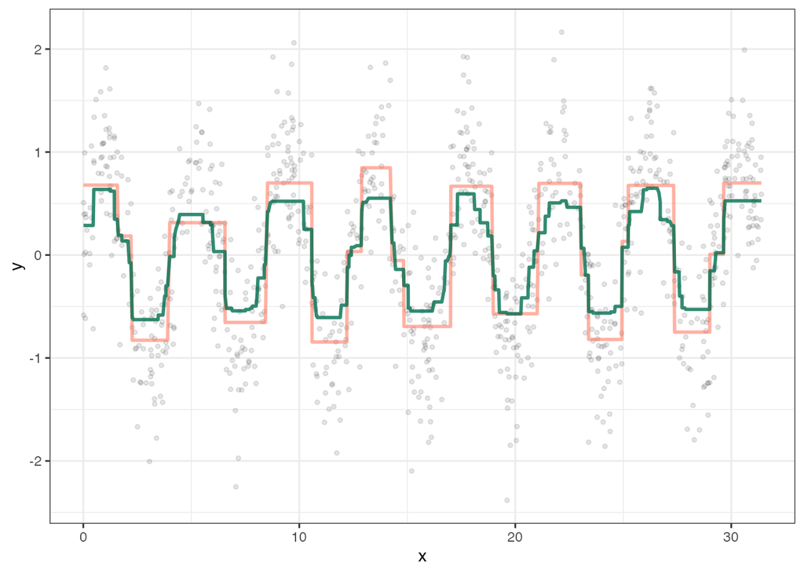

```r
library(rpart)
library(tidyverse)

# Create dataframe
set.seed(1234)
learning_rate <- 0.03

n <- 1000
x <- sort(runif(n) * 10 * pi)
y <- sin(1.5*x) + rnorm(n, 0, 0.5)  # ノイズの分散を小さくする
df1 <- data.frame(x = x, y = y)

# Fit base tree model
fit <- rpart(y ~ x, data = df1)
df1$y_pred_base <- predict(fit)
y_boost_lr <- predict(fit) * learning_rate
df1$y_res <- df1$y - y_boost_lr
y_boost <- y_boost_lr

# Boosting m times
loops <- 50
for (t in 1:loops) {
  fit <- rpart(y_res ~ x, data = df1)
  y_boost_lr <- predict(fit, newdata = df1) * learning_rate
  df1$y_res <- df1$y_res - y_boost_lr
  y_boost <- cbind(y_boost, y_boost_lr)
}

# Sum residuals
y <- apply(y_boost[, 1:loops], 1, sum)
df2 <- data.frame(x = df1$x, res = y)

# Plot
ggplot() +
  geom_point(data = df1, aes(x, y), size = 1, alpha = 0.1) +
  geom_line(data  = df1, aes(x, y_pred_base), size = 1, alpha = 0.5, col = 'tomato') +
  geom_line(data  = df2, aes(x, res), size = 1, alpha = 0.8, col = '#006E4F') +
  theme_bw()
```

## 勾配ブースティング(分類)のイメージ

次は分類を目的とした勾配ブースティング。回帰のときと流れは同じではあるものの、分類問題に対してそのまま適用すると問題が発生するので、その点は分類用に修正される。例えば回帰のように残差を足し合わせていくと、確率が0-1の範囲を超えてしまう。

使用するデータは下記の通り。

| No | Like | Age | Color | LikeMovie(Y) |
| --- | --- | --- | --- | --- |
| 1 | Yes | 12 | Blue | Yes |
| 2 | Yes | 87 | Green | Yes |
| 3 | No | 44 | Blue | No |
| 4 | Yes | 19 | Red | No |
| 5 | No | 32 | Green | Yes |
| 6 | No | 14 | Blue | Yes |

まずは初期値の確率を計算する。初期予測確率は対数オッズで計算する。対数オッズは$log(4/2)=0.7$となる(説明のために丸めている)。計算にした対数オッズをシグモイド関数に代入し、確率を得る。

$$\begin{eqnarray}
Prob = \frac{e^{log(4/2)}}{1+e^{log(4/2)}} = 0.6667 = 0.7
\end{eqnarray}$$

予測確率と目的変数の残差を計算する。目的変数は2値変数であれば0-1に変換するのが一般的。そして、分類木と残差を計算する。分類木はここでは下記のようになったとする。

```
Color = Red
 └ Leaf(1): Left(yes): -0.7(4)
 └ Right(No)
   Age > 37
    └ Leaf(2): Left(yes): 0.3(2), -0.7(3)
    └ Leaf(3): Right(No): 0.3(1), 0.3(5), 0.3(6)
```

| No | Like | Age | Color | LikeMovie(Y) | Residual |
| --- | --- | --- | --- | --- | --- |
| 1 | Yes | 12 | Blue | 1 | 0.3 |
| 2 | Yes | 87 | Green | 1 | 0.3 |
| 3 | No | 44 | Blue | 0 | -0.7 |
| 4 | Yes | 19 | Red | 0 | -0.7 |
| 5 | No | 32 | Green | 1 | 0.3 |
| 6 | No | 14 | Blue | 1 | 0.3 |

そして、残差を変換するために下記の関数を利用する。このよくわからない変換式は後ほど解説する。

$$\begin{eqnarray}
\frac{\sum residuals_{i}}{\sum[ PreviousProbability_{i} * (1 -
PreviousProbability_{i})]}
\end{eqnarray}$$

各Reafを計算すると、下記のようになる。

$$\begin{eqnarray}
Leaf(1)&:& \frac{-0.7}{0.7 * (1 - 0.7)}=-3.3 \\
Leaf(2)&:& \frac{0.3+-0.7}{(0.7 * (1 - 0.7)) + (0.7 * (1 -
0.7))}=-1 \\
Leaf(3)&:& \frac{0.3+0.3+0.3}{(0.7 * (1 - 0.7)) + (0.7 * (1 -
0.7)) + (0.7 * (1 - 0.7))}=1.4
\end{eqnarray}$$

これで各レコードの確率の予測値を更新できる。学習率は0.8としている。説明のために数字を丸めている。

$$\begin{eqnarray}
No4 &:& 0.7+(0.8*-3.3)=-1.9 → \frac{e^{-1.9 }}{1+e^{-1.9 }} =
0.1 \\
No2,3 &:& 0.7+(0.8*-1)=-0.1 → \frac{e^{-0.1 }}{1+e^{-0.1 }} =
0.5 \\
No1,5,6 &:& 0.7+(0.8*1.4)=1.8 → \frac{e^{1.8}}{1+e^{1.8}} = 0.9
\\
\end{eqnarray}$$

これで確率の予測値が計算される。そして、新しい残差を計算する。

| No | Like | Age | Color | LikeMovie(Y) | Residual | Prob | Residual2 |
| --- | --- | --- | --- | --- | --- | --- | --- |
| 1 | Yes | 12 | Blue | 1 | 0.3 | 0.9 | 0.1 |
| 2 | Yes | 87 | Green | 1 | 0.3 | 0.5 | 0.5 |
| 3 | No | 44 | Blue | 0 | -0.7 | 0.5 | -0.5 |
| 4 | Yes | 19 | Red | 0 | -0.7 | 0.1 | -0.1 |
| 5 | No | 32 | Green | 1 | 0.3 | 0.9 | 0.1 |
| 6 | No | 14 | Blue | 1 | 0.3 | 0.9 | 0.1 |

そして、新しい残差に対して新しい分類木を作成し、これを繰り返していくことで、残差を小さくしていく。

### 負の対数尤度と損失関数の関係

説明のためにデータを小さくしておく。

| No | Like | Age | Color | LikeMovie(Y) |  |
| --- | --- | --- | --- | --- | --- |
| 1 | Yes | 12 | Blue | 1 |  |
| 2 | No | 87 | Green | 1 |  |
| 3 | No | 44 | Blue | 0 |  |

初期確率は、$exp(log(2/1))/ (1+exp(log(2/1)))=0.67$である。ここで対数尤度を考える。

$$\begin{eqnarray}
LogLikelihood &=& \sum_{i=1}^{N} y_{i}*log(p) +
(1-y_{i})log(1-p) \\
&=& [1*log(0.67)+(1-1)*log(1-0.67)] +
[1*log(0.67)+(1-1)*log(1-0.67)] + [0*log(0.67)+(1-0)*log(1-0.67)]\\
&=& log(0.67) + log(0.67) + log(1-0.67)
\end{eqnarray}$$

ロジスティック回帰などを行う場合も、対数尤度を最大化することを目的にする。対数尤度が最も大きい時、パラメタがもっともらしいためである。つまり、対数尤度を損失関数として使いたい場合、損失関数は、より小さい値がよりよく適合するモデルを表すので、対数尤度にに-1を掛ける必要がある。

$$\begin{eqnarray}
-LogLikelihood &=& -\left[\sum_{i=1}^{N} y_{i}*log(p) +
(1-y_{i})log(1-p) \right] \\
\end{eqnarray}$$

ここで1つの値だけに注文して式を変形してみる。4-5行目の変換は後述。この変形によって、データの負の対数尤度を予測確率$p$の関数で表現でき、これを損失関数として利用できる。

$$\begin{eqnarray}
-[y*log(p) + (1-y)log(1-p)] &=& -y*log(p) - (1-y)log(1-p) \\
&=& -y*log(p) - (1-p) - y*log(1-p) \\
&=& -y*[log(p) - log(1-p)] - log(1-p) \\
&=& -y*log(odds) - log(1-p) \\
&=& -y*log(odds) + log(1+e^{log(odds)}) \\
\end{eqnarray}$$

4-5行目の変換は下記の通りである。

$$\begin{eqnarray}
log(1-p) &=& log \left( 1 -
\frac{e^{log(odds)}}{1+e^{log(odds)}}\right) \\
&=& log \left(\frac{1+e^{log(odds)}}{1+e^{log(odds)}} -
\frac{e^{log(odds)}}{1+e^{log(odds)}}\right) \\
&=& log \left( \frac{1}{1+e^{log(odds)}}\right) \\
&=& log(1) - log(1+e^{log(odds)}) \\
&=& 0 - log(1+e^{log(odds)}) \\
&=& - log(1+e^{log(odds)})
\end{eqnarray}$$

負の対数関数は、微分可能な損失関数として表現できる。

$$\begin{eqnarray}
\frac{\partial (-y*log(odds) + log(1+e^{log(odds)}))}{\partial \
log(odds)} &=& -y + \frac{1}{1+e^{log(odds)}}*e^{log(odds)} \\
&=& -y + \frac{e^{log(odds)}}{1+e^{log(odds)}} \\
&=& -y + p \\
\end{eqnarray}$$

### Step1: モデルの初期化

回帰の時と同様のアルゴリズムで予測値を得るわけではあるが、Stepについては、

$$\begin{eqnarray}
\text{Step1} &:& \text{Initialize model with a constant value}
\\
F_{0}(x) &=& \underset{\gamma} {\operatorname{argmin}}
\sum_{i=1}^{n}L(y_{i}, \gamma) \\
\end{eqnarray}$$

下記の損失関数が利用できる。$log(odds)=\gamma$である。これを最小にするわけなので、

$$\begin{eqnarray}
\underset{\gamma} {\operatorname{argmin}} \sum_{i=1}^{n}L(y_{i}, \gamma)
&=& -y*log(odds) + log(1+e^{log(odds)}) \\
&=& -1*log(odds) + log(1+e^{log(odds)}) -1*log(odds) +
log(1+e^{log(odds)}) -0*log(odds) + log(1+e^{log(odds)}) \\
\end{eqnarray}$$

あとは微分して0とおくと

$$\begin{eqnarray}
\frac{\partial L(y_{i}, \gamma)}{\partial \gamma} &=&
\frac{\partial (-1*log(odds) + log(1+e^{log(odds)}) -1*log(odds) +
log(1+e^{log(odds)}) -0*log(odds) + log(1+e^{log(odds)})) }{\partial
log(odds)} \\
&=& -1 + \frac{e^{log(odds)}}{1+e^{log(odds)}}-1 +
\frac{e^{log(odds)}}{1+e^{log(odds)}} -0 +
\frac{e^{log(odds)}}{1+e^{log(odds)}} \\
&=& -1 + p -1 + p -0 + p = 0 \\
p &=& \frac{2}{3}
\end{eqnarray}$$

となって、$F_{0}(x)=0.69$と計算できる。

$$\begin{eqnarray}
log(odds) = log \left(\frac{p}{1-p} \right) = log
\left(\frac{\frac{2}{3}}{1-\frac{2}{3}} \right) = log \left(\frac{2}{1}
\right) = 0.69
\end{eqnarray}$$
### Step2-A: 残差を計算する

次はStep2。損失関数を微分したものが必要ではあるが、それは計算済みである。

$$\begin{eqnarray}
\text{Step2-A} &:& \text{Compute} \ \ r_{im} \\
r_{im} &=& - \left[ \frac{\partial L(y_{i}, F(x_{i}))}{\partial
F(x_{i})}\right]_{F(x)=F_{m-1}(x)}, for \ i=1...n \\
\end{eqnarray}$$

$$\begin{eqnarray}
r_{im} &=& - \left[ \frac{\partial L(y_{i}, F(x_{i}))}{\partial
F(x_{i})}\right]_{F(x)=F_{m-1}(x)} \\
&=& - [-y + p ] \\
&=& \left(- [-y + \frac{e^{log(odds)}}{1 + e^{log(odds)}} ]
\right) \\
&=& \left(- [-y + \frac{e^{log(2/1)}}{1 + e^{log(2/1)}} ]
\right) \\
&=& y - 0.67 \\
\end{eqnarray}$$

残差を計算すると、下記のようになる。

| No | Like | Age | Color | LikeMovie(Y) | $r_{1,1}$ |  |
| --- | --- | --- | --- | --- | --- | --- |
| 1 | Yes | 12 | Blue | 1 | 1-0.67=0.33 |  |
| 2 | No | 87 | Green | 1 | 1-0.67=0.33 |  |
| 3 | No | 44 | Blue | 0 | 0-0.67=-0.67 |  |

### Step2-B: 残差に分類木を作成する

これで、回帰木(分類木)を作成する次のStep2-Bに進む。

$$\begin{eqnarray}
\text{Step2-B} &:& \text{Fit a regression tree to the} \ \
r_{im} \text{values and create terminal regions} \ \ R_{jm}, \text{for}
\ j = 1...J_m\\
\end{eqnarray}$$

ここでは下記の分類木ができたとする。数字はさきほど計算した残差で、丸括弧はレコードのNoを表し、今回は$j=1,m=1$である。

```
Like = Yes
 └ R_{1,1}: Left(Yes): 0.33(1)
 └ R_{1,2}: Right(No): 0.33(2),-0.67(3)
```

### Step2-C: 各リーフの残差を最小化する

次は、StepCの各リーフの損失関数の予測値を最小化するステップ。

$$\begin{eqnarray}
\text{Step2-C} &:& \text{For} \ j = 1...J_m \ \ \text{compute} \
\ \gamma_{jm} = \underset{\gamma} {\operatorname{argmin}} \sum_{x_{i}
\in R_{ij}} L(y_{i}, F_{m-1}(x_{i})+\gamma)
\\
\end{eqnarray}$$

$\gamma$を微分することは可能ではあるものの、すごく複雑になるため、ここで$\gamma$についての近似を考える。

$$\begin{eqnarray}
\gamma_{1,1} &=& \underset{\gamma} {\operatorname{argmin}}
\sum_{x_{i} \in R_{i1}} L(y_{i}, F_{0}(x_{i})+\gamma) \\
&=& \underset{\gamma} {\operatorname{argmin}} \sum_{x_{i} \in
R_{i1}} -y_{i} * [F_{m-1}(x_{i}) +
\gamma]+log(1+e^{F_{m-1}(x_{i})+\gamma}) \\
&=& \underset{\gamma} {\operatorname{argmin}} -y_{1} *
[F_{m-1}(x_{1}) + \gamma]+log(1+e^{F_{m-1}(x_{1})+\gamma}) \\
\end{eqnarray}$$

ここでは$\gamma$に関する2次のテイラー展開を考える。

$$\begin{eqnarray}
L(y_{1}, F_{m-1}(x_{1})+\gamma) &=& -y_{1} * [F_{m-1}(x_{1}) +
\gamma]+log(1+e^{F_{m-1}(x_{1})+\gamma}) \\
&\approx& L(y_{1}, F_{m-1}(x_{1})) + \frac{d }{d \ F()}(y_{1},
F_{m-1}(x_{1})) \gamma + \frac{1}{2} \frac{d^{2} }{d \ F()^{2}} (y_{1},
F_{m-1}(x_{1})) \gamma^{2}
\end{eqnarray}$$

損失関数をテイラー展開で近似することで、$\gamma$に関する導関数がシンプルに表現できる。

$$\begin{eqnarray}
\frac{d }{d} L(y_{1}, F_{m-1}(x_{1})+\gamma) &\approx& 0 +
\frac{d }{d \ F()}(y_{1}, F_{m-1}(x_{1})) + \frac{d^{2} }{d \ F()^{2}}
(y_{1}, F_{m-1}(x_{1})) \gamma
\end{eqnarray}$$

この導関数を0とおいて、$\gamma$に関して式変形する。$log(odds)$の2次導関数は後述する。

$$\begin{eqnarray}
\frac{d }{d} L(y_{1}, F_{m-1}(x_{1})+\gamma) &\approx& \frac{d
}{d \ F()}(y_{1}, F_{m-1}(x_{1})) + \frac{d^{2} }{d \ F()^{2}} (y_{1},
F_{m-1}(x_{1})) \gamma = 0 \\
\frac{d^{2} }{d \ F()^{2}} (y_{1}, F_{m-1}(x_{1})) \gamma &=& -
\frac{d }{d \ F()}(y_{1}, F_{m-1}(x_{1})) \\
\gamma &=& \frac{- \frac{d }{d \ F()}(y_{1},
F_{m-1}(x_{1}))}{\frac{d^{2} }{d \ F()^{2}} (y_{1}, F_{m-1}(x_{1}))} \\
\gamma &=& \frac{y_{1} -
\frac{e^{log(odds)}}{1+e^{log(odds)}}}{ \frac{d^{2} }{d \ F()^{2}}
(y_{1}, F_{m-1}(x_{1})) } \\
\gamma &=& \frac{y_{1} - p }{ \frac{d^{2} }{d \ F()^{2}}
(y_{1}, F_{m-1}(x_{1})) } \\
\gamma &=& \frac{Residuals }{ p * (1-p) }
\end{eqnarray}$$

$log(odds)$の2次導関数は下記の通り$ p * (1-p)$となる。

$$\begin{eqnarray}
\frac{d^{2} }{d \ F()^{2}} (y_{1}, F_{m-1}(x_{1})) &=&
-(1+e^{log(odds)})^{-2}e^{log(odds)}*e^{log(odds)}+(1+e^{log(odds)})^{-1}*e^{log(odds)}
\\
&=& \frac{-e^{2*log(odds)}}{(1+e^{log(odds)})^{2}} +
\frac{e^{log(odds)}}{1+e^{log(odds)}} \\
&=& \frac{-e^{2*log(odds)}}{(1+e^{log(odds)})^{2}} +
\frac{e^{log(odds)}}{1+e^{log(odds)}}
\frac{1+e^{log(odds)}}{1+e^{log(odds)}} \\
&=& \frac{-e^{2*log(odds)}}{(1+e^{log(odds)})^{2}} +
\frac{e^{log(odds) + e^{2*log(odds)}}} {(1+e^{log(odds)})^{2}} \\
&=& \frac{-e^{2*log(odds)}+ e^{log(odds)} +
e^{2*log(odds)}}{(1+e^{log(odds)})^{2}} \\
&=& \frac{e^{log(odds)} }{(1+e^{log(odds)})^{2}} \\
&=& \frac{e^{log(odds)}
}{(1+e^{log(odds)})(1+e^{log(odds)})} \\
&=& \frac{e^{log(odds)} }{(1+e^{log(odds)})}
* \frac{1}{(1+e^{log(odds)})} \\
&=& p * (1-p)
\end{eqnarray}$$

少し前に行っていた$\gamma_{11}$の計算に戻ると、

$$\begin{eqnarray}
\gamma_{1,1} &=& \frac{Residuals }{ p * (1-p) }
&=& \frac{0.33}{0.67*(1-0.67)}
&=& 1.5
\end{eqnarray}$$

となる。$\gamma_{21}$の計算も同様に行うと、

$$\begin{eqnarray}
\gamma_{2,1} &=& \underset{\gamma} {\operatorname{argmin}}
\sum_{x_{i} \in R_{i1}} L(y_{i}, F_{0}(x_{i})+\gamma) \\
&=& L(y_{2}, F_{0}(x_{2})+\gamma) + L(y_{3},
F_{0}(x_{3})+\gamma) \\
&=& \frac{Residuals_{2} + Residuals_{3} }{ (p_{2} *
(1-p_{2}))+p_{3} * (1-p_{3})} \\
&=& \frac{ 0.33-0.67 }{ (0.67 * (1-0.67))+0.67 * (1-0.67)} \\
&=& -0.77
\end{eqnarray}$$

と計算できる。まとめておく。

$$\begin{eqnarray}
\gamma_{1,1} &=& 1.5 \\
\gamma_{2,1} &=& -0.77
\end{eqnarray}$$

### Step2-D: 予測値を更新する

やっとStep2-Dまでこれた。あとは予測確率を更新するだけ。

$$\begin{eqnarray}
\text{Step2-D} &:& \text{Update} F_{m}(x) = F_{m-1}(x) + \nu
\sum_{j=1}^{J_{m}} r_{jm} I(x \in R_{jm})
\end{eqnarray}$$

学習率は$\nu =0.8$として、$F_{1}(x)$を計算する。

つまり、リーフに属しているレコードごとに予測値が計算でき、下記の予測値が得られる。

| No | Like | Age | Color | LikeMovie(Y) | $r_{1,1}$ | $F_{1}(x)$ | $p_{1}(x)$ |
| --- | --- | --- | --- | --- | --- | --- | --- |
| 1 | Yes | 12 | Blue | 1 | 0.33 | 1.89 | exp(1.89)/(1+exp(1.89))=0.87 |
| 2 | No | 87 | Green | 1 | 0.33 | 0.07 | exp(0.07)/(1+exp(0.07))=0.52 |
| 3 | No | 44 | Blue | 0 | -0.67 | 0.07 | exp(0.07)/(1+exp(0.07))=0.52 |

これをブースティング回数分繰り返す。

## 参考文献

- [Gradient Boost Part 2 (of 4): Regression Details](https://www.youtube.com/watch?v=2xudPOBz-vs&t=1169s)
- [Gradient Boost Part 3 (of 4): Classification](https://www.youtube.com/watch?v=jxuNLH5dXCs&t=1s)
- [Gradient Boost Part 4 (of 4): Classification Details](https://www.youtube.com/watch?v=StWY5QWMXCw&t=2s)